# Retention Modelling

Webster

16 November 2021

# 1 Exercise overview

*We are looking at pseudo-data from a company.* In this exercise, we are trying to understand more about a recent subscription plan the company has launched in January 2015 (it is August 2015 now). We are interested in:

1. A model that predicts monthly retention rate for the different subscription price points
2. Based on the model, for each price point, what percentage of users is still subscribed after at least 12 months?
3. How do user country and source affect subscription retention rate? How would you use these findings to improve the company revenue?

# 2 Load and explore data

## 2.1 First, load the data

```r
#Set seed for reproducibility
set.seed(1003)
#Set directory
i_am("01. Retention modelling.rmd")

#Load data
df <- read_csv(here("raw","subscription.csv"))
```

Some columns require cleaning, we do them now.

```r
df <- df %>%
  mutate(subscription_signup_date =  paste("01",subscription_signup_date),
         subscription_signup_date = as.Date(subscription_signup_date, "%d %B, %Y"))

#Convert variables to factors
df[sapply(df, is.character)] <- lapply(df[sapply(df, is.character)], as.factor)


df %>%
  summary()
```

```
##     user_id       subscription_signup_date subscription_monthly_cost
##  Min.   :     1   Min.   :2015-01-01       Min.   :29.00
##  1st Qu.:125001   1st Qu.:2015-01-01       1st Qu.:29.00
##  Median :250000   Median :2015-01-01       Median :49.00
##  Mean   :250000   Mean   :2015-01-01       Mean   :48.47
##  3rd Qu.:375000   3rd Qu.:2015-01-01       3rd Qu.:49.00
##  Max.   :500000   Max.   :2015-01-01       Max.   :99.00
##
##     country                  source       billing_cycles    is_active
##  US     :91731   ads            :414469   Min.   :1.000   Min.   :0.0
##  UK     :91252   friend_referral: 24428   1st Qu.:1.000   1st Qu.:0.0
##  Germany:88944   seo            : 61103   Median :1.000   Median :0.0
##  France :51662                            Mean   :2.385   Mean   :0.1
##  India  :48027                            3rd Qu.:3.000   3rd Qu.:0.0
##  Italy  :47459                            Max.   :8.000   Max.   :1.0
##  (Other):80925
```

# 3 Modelling monthly retention rate

It appears that the $49 package is most popular, followed by $29 and then $99.

```r
#Let's first have a look at some basic summary stats
df %>%
  group_by(subscription_monthly_cost) %>%
  summarize(count = n())
```

```
## # A tibble: 3 × 2
##   subscription_monthly_cost  count
##                       <dbl>  <int>
## 1                        29 146362
## 2                        49 300397
## 3                        99  53241
```

Here we plot the evolution of retention rate over the course of 8 months. We see that for individuals who subscribe to the $99 plan, more than 80% of users unsubscribe after just one month. Situation is best for $29 plan - around 40% subscribers drop out after one month.

Overall, the retention rate does not look like it has a linear relationship with the duration of subscription. Therefore, it is not the best option to have a linear regression model here since that would impose a linear structure on the data. Instead, we can opt for:

1. Standard non-linear transformation of variables and see if it leads to a linear relationship (e.g. log transformations)
2. Use flexible models such as **generalised additive models (GAM)**

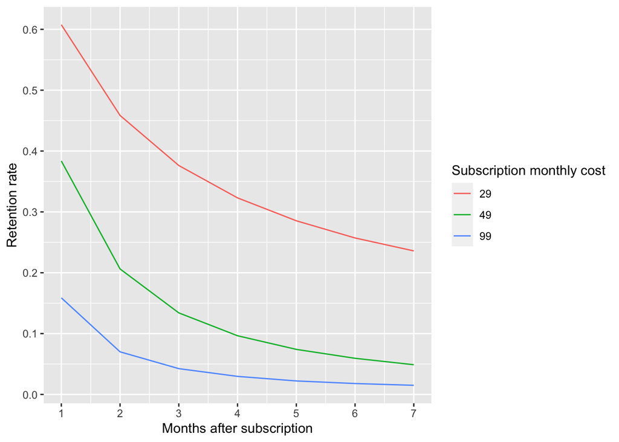

```r
graph_data <- df %>%
  group_by(subscription_monthly_cost, billing_cycles) %>%
  summarize(total_bills = n()) %>%
  ungroup(billing_cycles) %>%
  mutate (retention_rate = 1 - cumsum(total_bills)/sum(total_bills)) %>%
  # Remove 8 month billing cycle because all individuals at 8th month are still subscribed
  filter(billing_cycles <8)
graph_data %>%
  ggplot(aes(x = billing_cycles, y = retention_rate, color = as.factor(subscription_monthly_cost))) +
  geom_line() +
  scale_color_discrete("Subscription monthly cost") +
  scale_x_continuous("Months after subscription",
                     limits = c(1,7),
                     breaks = seq(1,7,1)) +
  scale_y_continuous("Retention rate",
                     breaks = seq(0,.7,.1))
```

To build the model, we can take the following approach:

1. We can start by segmenting the data into 3 separate datasets for each subscription price point.
2. We split the data into train and test.
3. We apply our model of choice (or multiple models) to the training data.
4. We test the performance of our model on the test data.
5. We draw any conclusions from the model.

## 3.1 Log transformation of variables

We can try to see if log transformations of the data can give us a linear relationship between retention and billing cycles. After applying log transformations to both x and y, we see that they do look very much like a linear relationship. In this case, we can try our usual linear methods (e.g. OLS).

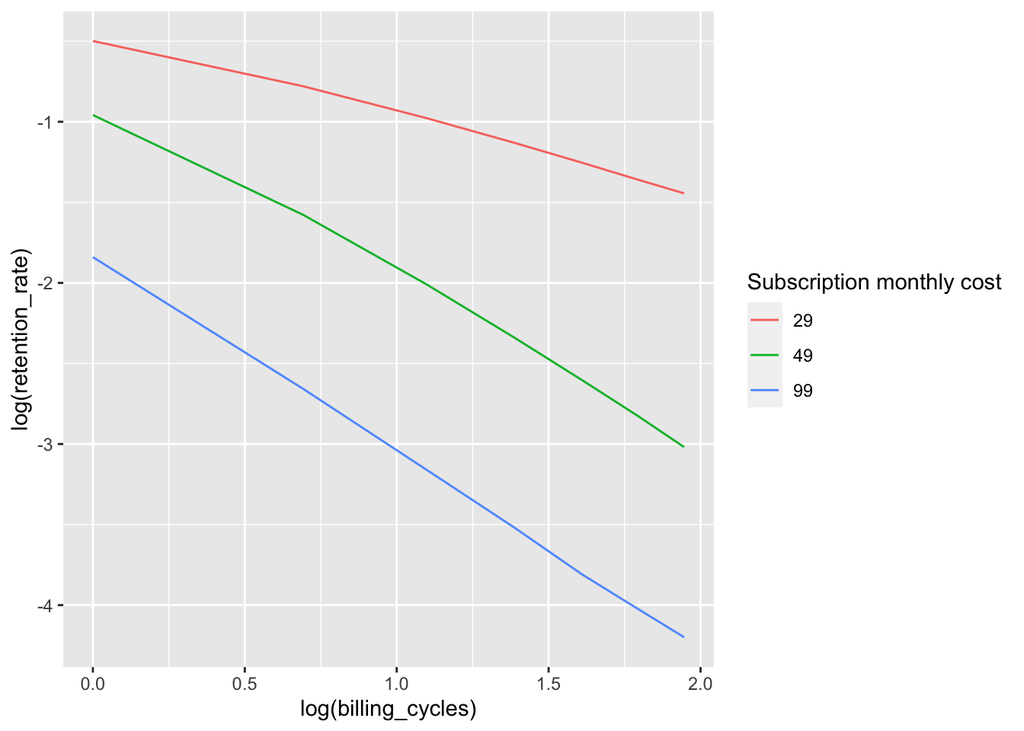

```r
graph_data %>%
  ggplot(aes(x = log(billing_cycles), y = log(retention_rate), color = as.factor(subscription_monthly_cost))) +
  geom_line() +
  scale_color_discrete("Subscription monthly cost")
```

## 3.2 Modelling using OLS

We now model using OLS and look at how well the model fits the data. The $R^2$ is an amazing 100% for all three price plans! In real life this is obviously not possible but since this is simulated data we are good to go!

```r
ols_models <-  graph_data %>%
  #Segment for each subscription package
  group_by(subscription_monthly_cost) %>%
  nest() %>%
  #Build model
  mutate(ols = map(.x = data,
                   ~lm(log(retention_rate) ~ log(billing_cycles), data = .x)))

# Now let's have a look at how well the model works
for (i in 1:3) {

  print(paste("Rsquare for subscription plan",
              ols_models$subscription_monthly_cost[[i]],
              "Model is",
              summary(ols_models$ols[[i]])$r.squared %>%
                round(2)))
}
```

```
## [1] "Rsquare for subscription plan 29 Model is 0.99"
## [1] "Rsquare for subscription plan 49 Model is 1"
## [1] "Rsquare for subscription plan 99 Model is 1"
```

# 4 What percentage of users is still subscribed after at least 12 months?

## 4.1 Predicting remaining subscribers

A simple `predict` function would be able to answer this question. We plot the predictions on a graph below.

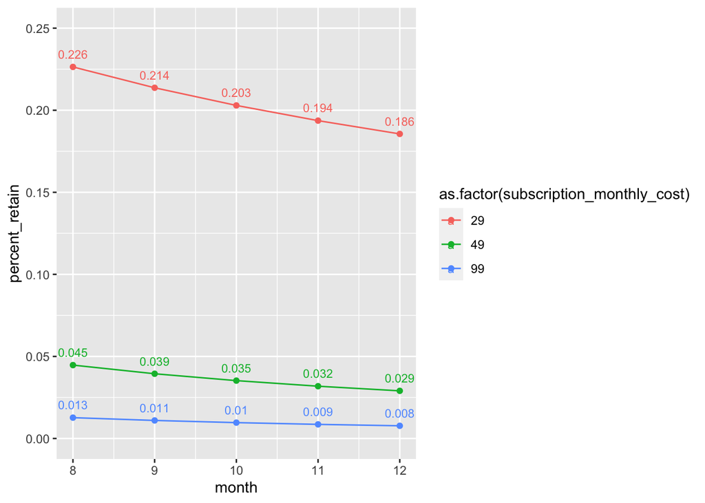

```r
#we want to predict x from 8 - 12 months
new_data <- tibble(billing_cycles = 8:12)

# Draw predictions
predictions <- ols_models %>%
  mutate(prediction = map(ols, ~predict(.x, new_data))) %>%
  unnest(prediction) %>%
  select(subscription_monthly_cost, prediction) %>%
  mutate(percent_retain = exp(prediction)) %>%
  bind_cols(tibble( month = rep(8:12, times = 3)))

predictions %>%
  ggplot(aes(x = month, y = percent_retain, color = as.factor(subscription_monthly_cost), label = percent_retain)) +
  geom_line() +
  geom_point()+
  geom_text(aes(label=round(percent_retain,3)),hjust=0.5, vjust=-1, size = 3) +
  scale_y_continuous(limits = c(0,0.25))
```

## 4.2 Deriving LTV of customers

Let’s get for each price point the average customer one year value. This can be defined as customer LTV. To find this, we need to first calculate for each month how much revenue we are *expected* to get from a single customer (e.g. if we see that only 50% of subscribers remain in month $X$, then the expected revenue is $50\%\times \text{subscription price per month}$). We then take the sum of all the monthly expected revenues over the course of 12 months to get the LTV of the customer.

We can see that the highest LTV is for users paying $99. However, since the retention rate for $29 package is much higher, the LTV would most definitely be higher than that of $99 if we expanded the time window (to a period longer than 12 months).

```r
#Combine actual and predicted data
pred_and_actual_data <-  graph_data %>%
  select(-total_bills) %>%
  bind_rows(predictions %>% select(-prediction) %>%
              rename(billing_cycles = month,
                     retention_rate = percent_retain ))

#Calculate revenue from each month
pred_and_actual_data <- pred_and_actual_data %>%
  mutate(revenue = subscription_monthly_cost * retention_rate)

for (i in c(29,49,99)) {
  #obtain subscription price
  temp_price <- pred_and_actual_data %>%
    filter(subscription_monthly_cost == i) %>%
    pull(subscription_monthly_cost) %>%
    unique()

  #Obtain total revenues (excluding month 0)
  temp_total_value_without_month_0 <- pred_and_actual_data %>%
    filter(subscription_monthly_cost == i) %>%
    summarize(total = sum(revenue)) %>%
    pull(total)

  #Calculate LTV from subscription price and retain %
  temp_ltv <- temp_price + temp_total_value_without_month_0

  print(paste("Average LTV of customers paying", i, "is", temp_ltv))
}
```

```
## [1] "Average LTV of customers paying 29 is 132.414068229475"
## [1] "Average LTV of customers paying 49 is 106.969528346779"
## [1] "Average LTV of customers paying 99 is 139.165617772801"
```

# 5 How do user country and source affect subscription retention rate?

## 5.1 Country

1. China and India have huge retention rate for the cheapest price point. They are also much more likely to choose the $29 option compared to the other countries
2. For most countries, the most proportion of initial users in the $49 plan. This is not ideal as the optimal plan is (i) $29 for China and India, (ii) $99 for the rest of the countries (as seen from the revenue charts) - *we would want to work with marketing to steer customers to these plans to increase our total revenues.*

> We could, for each country, change the UI such that the optimal plan is most obvious to the customer

```r
country_data <- df %>%
  group_by(subscription_monthly_cost, country) %>%
  summarize(
    #% of users left after 8 months
    retention_after_8_months = mean(is_active),
    # Total number of initial users
    total_initial_users = n(),
    # Average revenue per user
    revenue = mean(billing_cycles * subscription_monthly_cost)
  )
```

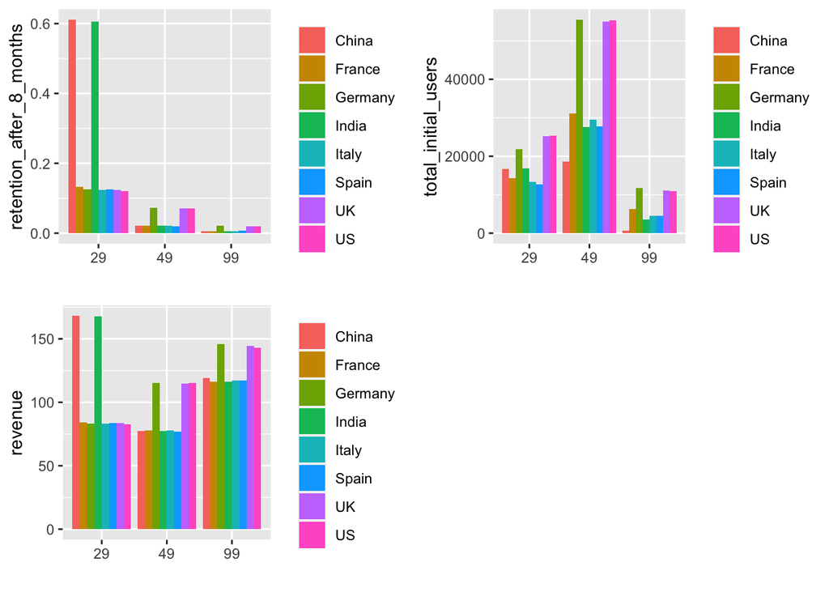

```r
#plot graphs
c_retention_plot <- country_data %>%
  ggplot(aes(x = as.factor(subscription_monthly_cost), y= retention_after_8_months, fill = country)) +
  geom_bar(stat = "identity", position = "dodge") +
  scale_x_discrete("")+
  scale_fill_discrete("")

c_users_plot <- country_data %>%
  ggplot(aes(x = as.factor(subscription_monthly_cost), y= total_initial_users, fill = country)) +
  geom_bar(stat = "identity", position = "dodge") +
  scale_x_discrete("")+
  scale_fill_discrete("")

c_revenue_plot <- country_data %>%
  ggplot(aes(x = as.factor(subscription_monthly_cost), y= revenue, fill = country)) +
  geom_bar(stat = "identity", position = "dodge") +
  scale_x_discrete("") +
  scale_fill_discrete("")

plot_grid(c_retention_plot, c_users_plot, c_revenue_plot)
```

## 5.2 Source

1. We get the most new customers from ads, but the retention is horrible (kind of expected).
2. Retention from friend referral is the best - but this is the source that provides the least new customers.
3. Revenue is highest for all three plans from friend referrals - despite the low number of total initial users, because a much higher proportion of users stay with the company, they end up contributing the most to revenues.

> Work with marketing to incentivise current users to engage in more friend referrals. For instance, we can provide incentives for current users (e.g. some rebate on their subscription) for every new friend they manage to refer.

```r
country_data <- df %>%
  group_by(subscription_monthly_cost, source) %>%
  summarize(
    #% of users left after 8 months
    retention_after_8_months = mean(is_active),
    # Total number of initial users
    total_initial_users = n(),
    # Average revenue per user
    revenue = mean(billing_cycles * subscription_monthly_cost)
  )
```

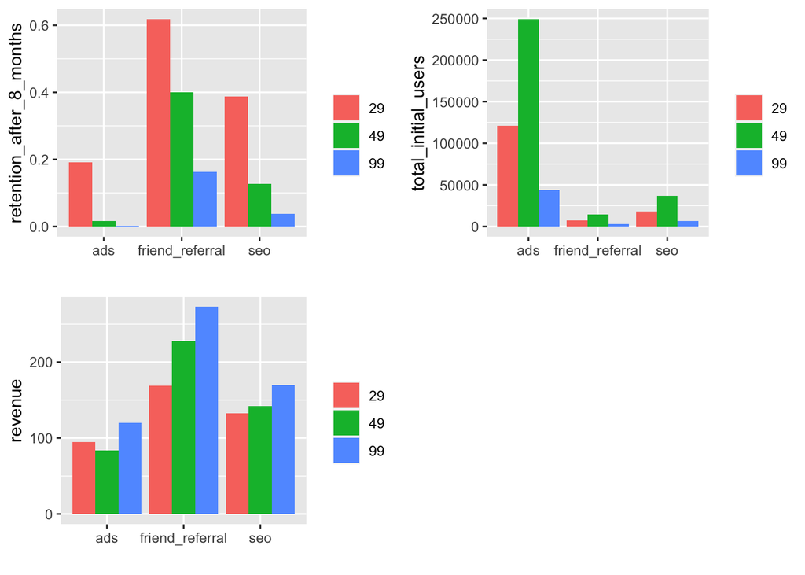

```r
#plot graphs
s_retention_plot <- country_data %>%
  ggplot(aes(x = source, y= retention_after_8_months, fill = as.factor(subscription_monthly_cost))) +
  geom_bar(stat = "identity", position = "dodge") +
  scale_x_discrete("")+
  scale_fill_discrete("")

s_users_plot <- country_data %>%
  ggplot(aes(x = source, y= total_initial_users, fill = as.factor(subscription_monthly_cost))) +
  geom_bar(stat = "identity", position = "dodge") +
  scale_x_discrete("")+
  scale_fill_discrete("")

s_revenue_plot <- country_data %>%
  ggplot(aes(x = source, y= revenue, fill = as.factor(subscription_monthly_cost))) +
  geom_bar(stat = "identity", position = "dodge") +
  scale_x_discrete("") +
  scale_fill_discrete("")

plot_grid(s_retention_plot, s_users_plot, s_revenue_plot)
```